# Projet réalisé par Aridhi Houssem Groupe A

## Projet Data Mining

### Base de données et introduction

La base de données sur le diabète des Indiens Pima est un ensemble de données largement utilisé dans le domaine de la recherche médicale et plus particulièrement dans l'étude du diabète. La base de données contient des informations sur les patientes d'origine indienne Pima, âgées de 21 ans ou plus. Les données ont été collectées par l'Institut national du diabète et des maladies digestives et rénales. L'objectif de ce cahier est d'utiliser la base de données sur le diabète des Indiens Pima pour construire un modèle prédictif du diabète. Nous utiliserons les paquets de science des données les plus populaires en Python, tels que pandas, numpy, seaborn, matplotlib et scikit-learn. Notre objectif est d'utiliser les informations contenues dans l'ensemble de données pour prédire avec précision si un patient est diabétique ou non.

### Variable d'interet

La variable d'interet est la variable "outcome" et c'est la variable qui nous donne si la personne est diabétique ou non. 1 si diabétique et 0 sinon

### Sommaire

- Importations
- Importation de la base
- Description de la base
- Regression logistique (Sklearn)
  - Selection des variables pour le modele
    - RFE
    - SelectKBest
  - Creation de modele (RFE)
  - Prediction(RFE) et évaluation de modele
  - Creation de modele (SelectKBest)
  - Prediction et évaluation de modele(SelectKBest)
- Regression logistique (Statmodel)
  - Création de modele
  - Resumé de modele
  - Prédiction
- Comparaison des trois modeles
- Decision Tree
  - Creation de l'arbre de decision
  - Analyse de modele
  - Affichage de l'arbre
  - L'importance de chaque variable pour le modele
  - L'optimisation et le choix de meilleur modele
  - Creation de model optimisé et affichage de la nouvelle arbre
  - L'importance de chaque variable pour le modele
  - Evaluation de model optimisé
  - Optimisation de model par le choix de alpha qui maximise le recall
  - Affichage de l'arbre de meilleur modele
  - Importance des variables pour le modele
  - Evaluation de modele
- Random Forest
  - Création de modele
  - Les parametres de modele
  - Prediction et Evaluation
  - Réglage des hyperparamètres à l'aide de RandomizedSearch CV
  - Creation de model optimisé
    - Imprimer les meilleures parametres
    - Utilisation des meilleures parametres
  - Evaluation de model
- Conclusion

### Importations

```python
import pandas as pd
import numpy as np
import matplotlib.pyplot as plt
import seaborn as sns
from sklearn.feature_selection import RFE,SelectKBest,chi2, f_regression
from sklearn.linear_model import LogisticRegression
from sklearn.model_selection import train_test_split,GridSearchCV,RandomizedSearchCV
from sklearn import preprocessing
from sklearn.metrics import confusion_matrix,ConfusionMatrixDisplay,plot_confusion_matrix
from sklearn.metrics import classification_report,accuracy_score,f1_score,precision_score,recall_score,roc_curve,roc_auc_score
import statsmodels.formula.api as smf
from sklearn.metrics import mean_squared_error,make_scorer,r2_score
from sklearn.tree import DecisionTreeClassifier
from sklearn.ensemble import RandomForestClassifier,RandomForestRegressor
%matplotlib inline
```

### Importation de la base

```python
df = pd.read_csv('C:/Users/user/Desktop/Projet ML/diabetes.csv')
df.head()
```

|  | Pregnancies | Glucose | BloodPressure | SkinThickness | Insulin | BMI | DiabetesPedigreeFunction | Age | Outcome |
| --- | --- | --- | --- | --- | --- | --- | --- | --- | --- |
| 0 | 6 | 148 | 72 | 35 | 0 | 33.6 | 0.627 | 50 | 1 |
| 1 | 1 | 85 | 66 | 29 | 0 | 26.6 | 0.351 | 31 | 0 |
| 2 | 8 | 183 | 64 | 0 | 0 | 23.3 | 0.672 | 32 | 1 |
| 3 | 1 | 89 | 66 | 23 | 94 | 28.1 | 0.167 | 21 | 0 |
| 4 | 0 | 137 | 40 | 35 | 168 | 43.1 | 2.288 | 33 | 1 |

```python
df.info()
```

```
<class 'pandas.core.frame.DataFrame'>
RangeIndex: 768 entries, 0 to 767
Data columns (total 9 columns):
 #   Column                    Non-Null Count  Dtype
---  ------                    --------------  -----
 0   Pregnancies               768 non-null    int64
 1   Glucose                   768 non-null    int64
 2   BloodPressure             768 non-null    int64
 3   SkinThickness             768 non-null    int64
 4   Insulin                   768 non-null    int64
 5   BMI                       768 non-null    float64
 6   DiabetesPedigreeFunction  768 non-null    float64
 7   Age                       768 non-null    int64
 8   Outcome                   768 non-null    int64
dtypes: float64(2), int64(7)
memory usage: 54.1 KB
```

### Description de la base

```python
# Valeurs nulles
df.isna().any()
```

```
Pregnancies                 False
Glucose                     False
BloodPressure               False
SkinThickness               False
Insulin                     False
BMI                         False
DiabetesPedigreeFunction    False
Age                         False
Outcome                     False
dtype: bool
```

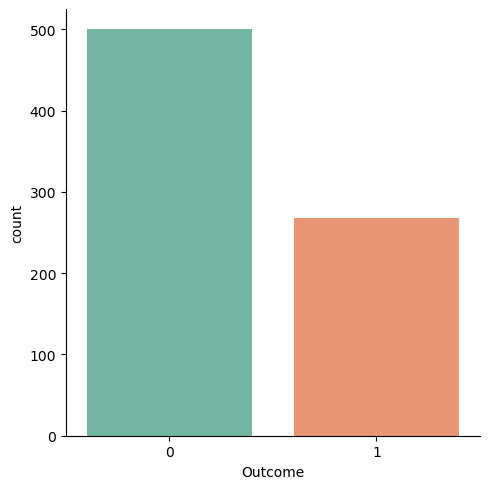

```python
# Visualisation du résultat
df_temp = df.copy()
sns.catplot(x="Outcome", kind="count", data=df_temp, palette="Set2")
plt.show()
```

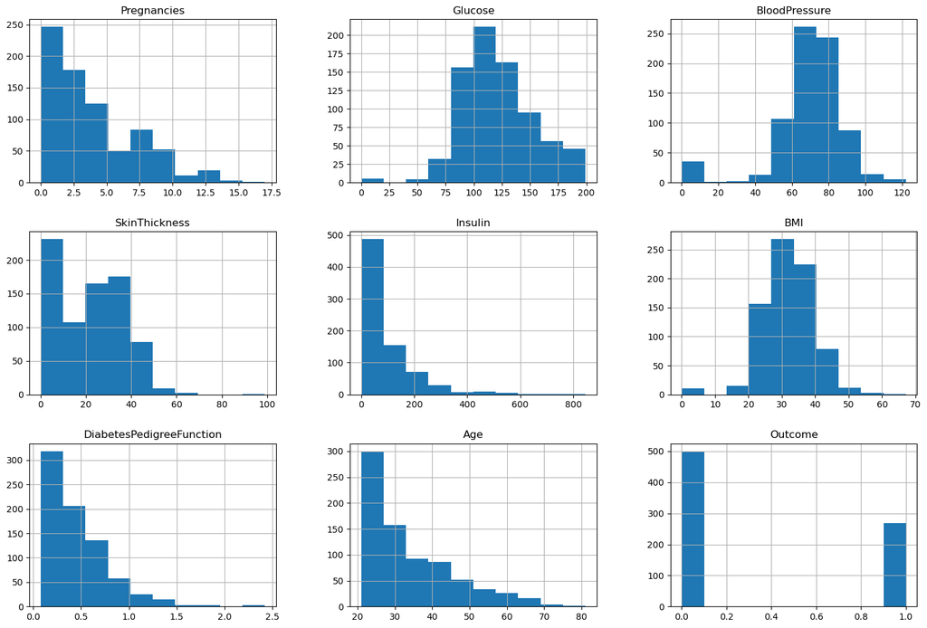

```python
# Distribution des variables
df.hist(figsize=(18,12))
plt.show()
```

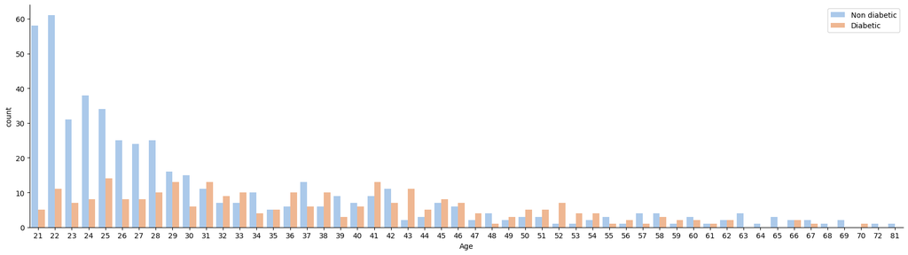

```python
# La visualisation de l'âge des diabétiques
ax = sns.catplot(x="Age", kind="count",hue="Outcome",data=df_temp, palette="pastel", legend=False)
ax.fig.set_figwidth(20)
plt.legend(loc='upper right', labels= ["Non diabetic", "Diabetic"])
plt.show()
```

```python
# Description des données
df.describe()
```

|  | Pregnancies | Glucose | BloodPressure | SkinThickness | Insulin | BMI | DiabetesPedigreeFunction | Age | Outcome |
| --- | --- | --- | --- | --- | --- | --- | --- | --- | --- |
| count | 768.000000 | 768.000000 | 768.000000 | 768.000000 | 768.000000 | 768.000000 | 768.000000 | 768.000000 | 768.000000 |
| mean | 3.845052 | 120.894531 | 69.105469 | 20.536458 | 79.799479 | 31.992578 | 0.471876 | 33.240885 | 0.348958 |
| std | 3.369578 | 31.972618 | 19.355807 | 15.952218 | 115.244002 | 7.884160 | 0.331329 | 11.760232 | 0.476951 |
| min | 0.000000 | 0.000000 | 0.000000 | 0.000000 | 0.000000 | 0.000000 | 0.078000 | 21.000000 | 0.000000 |
| 25% | 1.000000 | 99.000000 | 62.000000 | 0.000000 | 0.000000 | 27.300000 | 0.243750 | 24.000000 | 0.000000 |
| 50% | 3.000000 | 117.000000 | 72.000000 | 23.000000 | 30.500000 | 32.000000 | 0.372500 | 29.000000 | 0.000000 |
| 75% | 6.000000 | 140.250000 | 80.000000 | 32.000000 | 127.250000 | 36.600000 | 0.626250 | 41.000000 | 1.000000 |
| max | 17.000000 | 199.000000 | 122.000000 | 99.000000 | 846.000000 | 67.100000 | 2.420000 | 81.000000 | 1.000000 |

### Regression logistique (Sklearn)

```python
# Division de la base de données en base d'apprentissage et base de testing
x = df_temp.drop(['Outcome'], axis = 1)
y = df_temp.loc[:,"Outcome"].values
x_train, x_test, y_train, y_test = train_test_split(x, y, test_size = 0.2, random_state = 123)
```

#### Selection des variables pour le modele

##### RFE

RFE (Recursive Feature Elimination) est un algorithme de sélection des caractéristiques qui fonctionne en supprimant récursivement des caractéristiques d'un ensemble de données et en construisant un modèle sur les caractéristiques restantes jusqu'à ce qu'un nombre désiré de caractéristiques soit atteint.

L'algorithme commence par former un modèle sur toutes les caractéristiques disponibles et classe les caractéristiques en fonction de leur importance dans le modèle. La caractéristique ayant le score d'importance le plus bas est alors retirée de l'ensemble de données et le modèle est entraîné à nouveau sur les caractéristiques restantes. Ce processus est répété jusqu'à ce que le nombre souhaité de caractéristiques soit atteint ou jusqu'à ce qu'un critère d'arrêt soit rempli.

```python
# Application d'RFE pour choisir le 5 meilleures variables pour le modele
model = LogisticRegression()
rfe = RFE(estimator=model, n_features_to_select=5)
fit = rfe.fit(x_train, y_train)

print("Num Features: %s" % (fit.n_features_))
print("Selected Features: %s" % (fit.support_))
print("Feature Ranking: %s" % (fit.ranking_))
```

```
Num Features: 5
Selected Features: [ True  True False False False  True  True  True]
Feature Ranking: [1 1 2 4 3 1 1 1]
```

##### SelectKBest

SelectKBest est un algorithme de sélection de caractéristiques qui sélectionne les K caractéristiques les plus performantes d'un ensemble de données sur la base d'un test statistique. L'algorithme évalue chaque caractéristique indépendamment et attribue un score en fonction de sa corrélation avec la variable cible.

```python
select = SelectKBest(score_func=chi2, k=5)
z = select.fit_transform(x_train,y_train)
```

```python
filter = select.get_support()

features = x.columns
print(features[filter])
```

```
Index(['Glucose', 'SkinThickness', 'Insulin', 'BMI', 'Age'], dtype='object')
```

On va selectionner les variables : Pregnancies,Glucose,Bmi,DiabetesPedigreeFunction,Age

#### Creation de modele (RFE)

```python
x_train_selected=x_train[["Pregnancies","Glucose","BMI","DiabetesPedigreeFunction","Age"]]
x_test_selected=x_test[["Pregnancies","Glucose","BMI","DiabetesPedigreeFunction","Age"]]
lr = LogisticRegression(max_iter = 1000)
lr.fit(x_train_selected, y_train)
```

```
LogisticRegression(max_iter=1000)
```

#### Prediction(RFE) et évaluation de modele

Matrice de confusion : La matrice de confusion est une matrice qui permet d'évaluer la performance d'un modèle de classification binaire. La matrice de confusion est constituée de quatre valeurs : vrai positif (VP), faux positif (FP), vrai négatif (VN) et faux négatif (FN).

Un vrai positif correspond à un cas où le modèle prédit correctement une classe positive, c'est-à-dire qu'il a correctement identifié un cas comme appartenant à la classe positive.

Un faux positif correspond à un cas où le modèle prédit à tort une classe positive, c'est-à-dire qu'il a identifié un cas comme appartenant à la classe positive alors qu'il appartient en réalité à la classe négative.

Un vrai négatif correspond à un cas où le modèle prédit correctement une classe négative, c'est-à-dire qu'il a correctement identifié un cas comme n'appartenant pas à la classe positive.

Un faux négatif correspond à un cas où le modèle prédit à tort une classe négative, c'est-à-dire qu'il a identifié un cas comme n'appartenant pas à la classe positive alors qu'il appartient en réalité à la classe positive.

Precision: Cette métrique mesure la proportion de prédictions positives qui sont effectivement correctes. Pour la classe 0, la précision est de 0,78, ce qui signifie que sur toutes les instances prédites comme appartenant à la classe 0, 78 % étaient effectivement des vrais positifs. Pour la classe 1, la précision est de 0,79, indiquant que sur toutes les instances prédites comme appartenant à la classe 1, 79 % étaient effectivement des vrais positifs.

Recall: Cette métrique mesure la proportion d'instances de vrais positifs qui ont été correctement prédites par le modèle. Pour la classe 0, le rappel est de 0,91, indiquant que sur toutes les instances qui appartiennent réellement à la classe 0, le modèle a correctement identifié 91 %. Pour la classe 1, le rappel est de 0,59, indiquant que sur toutes les instances qui appartiennent réellement à la classe 1, le modèle n'a identifié que 59 %.

F1-score: Cette métrique est la moyenne harmonique de la précision et du rappel, et fournit une mesure équilibrée de la performance du modèle. Pour la classe 0, le F1-score est de 0,84, indiquant une bonne performance globale, tandis que pour la classe 1, le F1-score est de 0,67, indiquant qu'il y a une marge d'amélioration.

AUC : Un score AUC (Area Under the Curve) de 0,8424928160919541 indique que la capacité du modèle à distinguer les classes positives et négatives est assez bonne. Le score AUC varie de 0 à 1, où 0,5 signifie que le modèle ne performe pas mieux que le hasard, et 1 signifie que le modèle distingue parfaitement les classes positives et négatives.

Par conséquent, un score AUC de 0,8424928160919541 indique que le modèle performe mieux que le hasard, mais qu'il reste de la place pour l'amélioration. Il est essentiel de prendre en compte le problème spécifique et le contexte dans lequel le modèle est utilisé pour déterminer si le score est acceptable ou non. En général, un score AUC supérieur à 0,7 est considéré comme acceptable, tandis qu'un score supérieur à 0,9 est considéré comme excellent.

Courbe ROC : La courbe ROC (Receiver Operating Characteristic) est un outil graphique utilisé pour évaluer la performance d'un modèle de classification binaire en fonction de différents seuils de décision. La courbe ROC représente la sensibilité du modèle en fonction de la spécificité, où la sensibilité est la proportion de vrais positifs (VP) détectés par le modèle et la spécificité est la proportion de vrais négatifs (VN) détectés par le modèle.

La courbe ROC est obtenue en traçant un graphique de la sensibilité en fonction de 1 - la spécificité pour différents seuils de décision. Chaque point sur la courbe ROC correspond à un seuil de décision différent pour le modèle. Plus la courbe ROC est proche du coin supérieur gauche du graphique, plus le modèle est performant, car cela signifie que le modèle détecte un grand nombre de vrais positifs tout en ayant un faible taux de faux positifs.

AIC : L'AIC (Akaike Information Criterion) est une mesure de l'ajustement relatif d'un modèle statistique, qui prend en compte la qualité de l'ajustement et la complexité du modèle. L'AIC est basé sur la théorie de l'information et est couramment utilisé en statistique pour comparer différents modèles et sélectionner le modèle qui convient le mieux aux données.

```python
y_pred = lr.predict(x_test_selected)
cnf_matrix=confusion_matrix(y_pred,y_test)
```

[figure not shown]

```python
#plotting confusion matrix
class_names = [0,1]
fig, ax = plt.subplots()
tick_marks = np.arange(len(class_names))
plt.xticks(tick_marks, class_names)
plt.yticks(tick_marks, class_names)

#create heatmap
sns.heatmap(pd.DataFrame(cnf_matrix), annot=True, cmap="YlGnBu", fmt='g')
ax.xaxis.set_label_position("top")
plt.tight_layout()
plt.title('Confusion Matrix', y=1.1)
plt.ylabel('Actual Label')
plt.xlabel('Predicted Label')
```

```python
print(classification_report(y_test, y_pred))
```

```
              precision    recall  f1-score   support

           0       0.78      0.91      0.84        96
           1       0.79      0.59      0.67        58

    accuracy                           0.79       154
   macro avg       0.79      0.75      0.76       154
weighted avg       0.79      0.79      0.78       154
```

```python
#use model to predict probability that given y value is 1
y_pred_proba = lr.predict_proba(x_test_selected)[::,1]

#calculate AUC of model
auc = roc_auc_score(y_test, y_pred_proba)

#print AUC score
print(auc)
```

```
0.8424928160919541
```

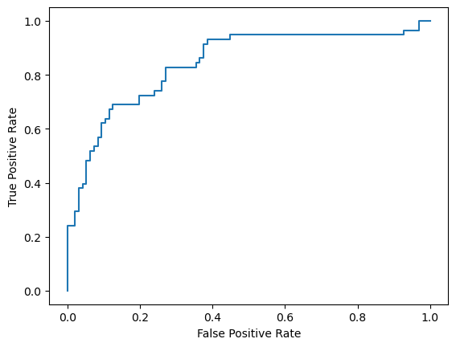

```python
def plot_roc_curve(true_y, y_prob):
    """
    plots the roc curve based of the probabilities
    """

    fpr, tpr, thresholds = roc_curve(true_y, y_prob)
    plt.plot(fpr, tpr)
    plt.xlabel('False Positive Rate')
    plt.ylabel('True Positive Rate')
plot_roc_curve(y_test, y_pred_proba)
```

```python
# calculate aic for regression
def calculate_aic(n, mse, num_params):
 aic = n * np.log(mse) + 2 * num_params
 return aic

# number of parameters
num_params = len(lr.coef_) + 1
print('Number of parameters: %d' % (num_params))
# calculate the error
mse = mean_squared_error(y_test, y_pred)
print('MSE: %.3f' % mse)
# calculate the aic
aic = calculate_aic(len(y), mse, num_params)
print('AIC: %.3f' % aic)
```

```
Number of parameters: 2
MSE: 0.214
AIC: -1179.062
```

#### Creation de modele (SelectKBest)

```python
x_train_selected=x_train[['Glucose', 'SkinThickness', 'Insulin', 'BMI', 'Age']]
x_test_selected=x_test[['Glucose', 'SkinThickness', 'Insulin', 'BMI', 'Age']]
lr = LogisticRegression(max_iter = 1000)
lr.fit(x_train_selected, y_train)
```

```
LogisticRegression(max_iter=1000)
```

#### Prediction et évaluation de modele(SelectKBest)

```python
y_pred = lr.predict(x_test_selected)
cnf_matrix=confusion_matrix(y_pred,y_test)
```

[figure not shown]

```python
#plotting confusion matrix
class_names = [0,1]
fig, ax = plt.subplots()
tick_marks = np.arange(len(class_names))
plt.xticks(tick_marks, class_names)
plt.yticks(tick_marks, class_names)

#create heatmap
sns.heatmap(pd.DataFrame(cnf_matrix), annot=True, cmap="YlGnBu", fmt='g')
ax.xaxis.set_label_position("top")
plt.tight_layout()
plt.title('Confusion Matrix', y=1.1)
plt.ylabel('Actual Label')
plt.xlabel('Predicted Label')
```

```python
print(classification_report(y_test, y_pred))
```

```
              precision    recall  f1-score   support

           0       0.77      0.90      0.83        96
           1       0.76      0.55      0.64        58

    accuracy                           0.77       154
   macro avg       0.76      0.72      0.73       154
weighted avg       0.77      0.77      0.76       154
```

```python
#use model to predict probability that given y value is 1
y_pred_proba = lr.predict_proba(x_test_selected)[::,1]

#calculate AUC of model
auc = roc_auc_score(y_test, y_pred_proba)

#print AUC score
print(auc)
```

```
0.8274066091954023
```

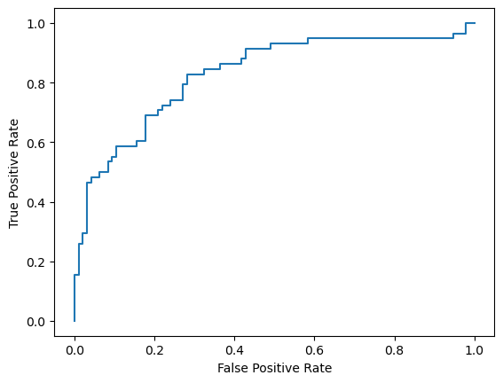

```python
def plot_roc_curve(true_y, y_prob):
    """
    plots the roc curve based of the probabilities
    """

    fpr, tpr, thresholds = roc_curve(true_y, y_prob)
    plt.plot(fpr, tpr)
    plt.xlabel('False Positive Rate')
    plt.ylabel('True Positive Rate')
plot_roc_curve(y_test, y_pred_proba)
```

```python
# calculate aic for regression
def calculate_aic(n, mse, num_params):
 aic = n * np.log(mse) + 2 * num_params
 return aic

# number of parameters
num_params = len(lr.coef_) + 1
print('Number of parameters: %d' % (num_params))
# calculate the error
mse = mean_squared_error(y_test, y_pred)
print('MSE: %.3f' % mse)
# calculate the aic
aic = calculate_aic(len(y), mse, num_params)
print('AIC: %.3f' % aic)
```

```
Number of parameters: 2
MSE: 0.234
AIC: -1112.237
```

### Regression logistique (Statmodel)

#### Creation de modele

```python
log_reg = smf.logit("Outcome ~ Pregnancies + Glucose + BloodPressure + SkinThickness + Insulin + BMI + DiabetesPedigreeFunction + Age ",data=df).fit()
```

```
Optimization terminated successfully.
         Current function value: 0.470993
         Iterations 6
```

#### Resumé de modele

```python
print(log_reg.summary())
```

```
                           Logit Regression Results
==============================================================================
Dep. Variable:                Outcome   No. Observations:                  768
Model:                          Logit   Df Residuals:                      759
Method:                           MLE   Df Model:                            8
Date:                Fri, 28 Apr 2023   Pseudo R-squ.:                  0.2718
Time:                        15:08:35   Log-Likelihood:                -361.72
converged:                       True   LL-Null:                       -496.74
Covariance Type:            nonrobust   LLR p-value:                 9.652e-54
============================================================================================
                               coef    std err          z      P>|z|      [0.025      0.975]
--------------------------------------------------------------------------------------------
Intercept                   -8.4047      0.717    -11.728      0.000      -9.809      -7.000
Pregnancies                  0.1232      0.032      3.840      0.000       0.060       0.186
Glucose                      0.0352      0.004      9.481      0.000       0.028       0.042
BloodPressure               -0.0133      0.005     -2.540      0.011      -0.024      -0.003
SkinThickness                0.0006      0.007      0.090      0.929      -0.013       0.014
Insulin                     -0.0012      0.001     -1.322      0.186      -0.003       0.001
BMI                          0.0897      0.015      5.945      0.000       0.060       0.119
DiabetesPedigreeFunction     0.9452      0.299      3.160      0.002       0.359       1.531
Age                          0.0149      0.009      1.593      0.111      -0.003       0.033
============================================================================================
```

```python
# AIC
print(log_reg.aic)
```

```
741.4453777741688
```

#### prediction

```python
# performing predictions on the test dataset
yhat = log_reg.predict(x_test)
prediction = list(map(round, yhat))

# confusion matrix
cm = confusion_matrix(y_test, prediction)

# accuracy score of the model
print('Test accuracy = ', accuracy_score(y_test, prediction))
```

```
Test accuracy =  0.8181818181818182
```

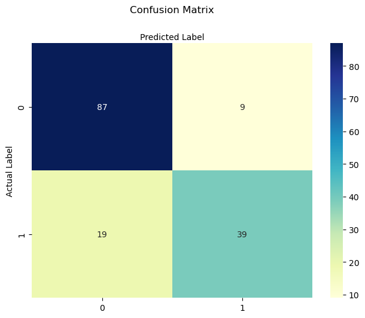

```python
#plotting confusion matrix
class_names = [0,1]
fig, ax = plt.subplots()
tick_marks = np.arange(len(class_names))
plt.xticks(tick_marks, class_names)
plt.yticks(tick_marks, class_names)

#create heatmap
sns.heatmap(pd.DataFrame(cm), annot=True, cmap="YlGnBu", fmt='g')
ax.xaxis.set_label_position("top")
plt.tight_layout()
plt.title('Confusion Matrix', y=1.1)
plt.ylabel('Actual Label')
plt.xlabel('Predicted Label')
```

```python
print(classification_report(y_test, prediction))
```

```
              precision    recall  f1-score   support

           0       0.82      0.91      0.86        96
           1       0.81      0.67      0.74        58

    accuracy                           0.82       154
   macro avg       0.82      0.79      0.80       154
weighted avg       0.82      0.82      0.81       154
```

```python
wald_test = log_reg.wald_test_terms(scalar=True)
print(wald_test)
```

```
                                chi2        P>chi2  df constraint
Intercept                 137.545608  9.161475e-32              1
Pregnancies                14.746674  1.229642e-04              1
Glucose                    89.896794  2.509132e-21              1
BloodPressure               6.453712  1.107208e-02              1
SkinThickness               0.008048  9.285152e-01              1
Insulin                     1.748502  1.860652e-01              1
BMI                        35.346982  2.758957e-09              1
DiabetesPedigreeFunction    9.982931  1.579980e-03              1
Age                         2.537198  1.111920e-01              1
```

D'aprés le test de Wald pour ce modele on a la p-value des variables SkinThickness, Insulin et Age sont superieures a 0.05 alors ces trois variables ne sont pas significatives pour ce modele.

### Comparaison des trois modeles

Le critère d'information d'Akaike (AIC) est une mesure utilisée pour comparer différents modèles statistiques. Une valeur d'AIC plus faible indique un meilleur ajustement du modèle aux données.

Et en comparant la précision et le rappel des trois modèles, nous concluons que le troisième modèle est le meilleur pour l'application de la régression logistique.

### Decision Tree

```python
# Fonction qui fait la matrice de confusion
def make_confusion_matrix(y_actual,y_predict,title):
    fig, ax = plt.subplots(1, 1)

    cm = confusion_matrix(y_actual, y_predict, labels=[0,1])
    disp = ConfusionMatrixDisplay(confusion_matrix=cm,
                               display_labels=["No","Yes"])
    disp.plot(cmap="YlGnBu",colorbar=True,ax=ax)
    ax.set_title(title)
    plt.tick_params(axis=u'both', which=u'both',length=0)
    plt.grid(b=None,axis='both',which='both',visible=False)
    plt.show()
```

```python
# Fonction qui calcule le recall et la precision
def get_score(model):
    '''
    model : classifier to predict values of X

    '''
    ytrain_predict = model.predict(x_train)
    ytest_predict = model.predict(x_test)
    # accuracy on training set
    print("\x1b[0;30;47m \033[1mAccuracy : Train :\033[0m",
          model.score(x_train,y_train),
          "\x1b[0;30;47m \033[1mTest:\033[0m",
          model.score(x_test,y_test))
# accuracy on training set
    print("\x1b[0;30;47m \033[1mRecall   : Train :\033[0m",
          recall_score(y_train,ytrain_predict),
          "\x1b[0;30;47m \033[1mTest:\033[0m",
          recall_score(y_test,ytest_predict))
# accuracy on training set
    print("\x1b[0;30;47m \033[1mPrecision   : Train :\033[0m",
          precision_score(y_train,ytrain_predict),
          "\x1b[0;30;47m \033[1mTest:\033[0m",
          precision_score(y_test,ytest_predict))
    make_confusion_matrix(y_train,ytrain_predict,"Confusion Matric on Train Data")
    make_confusion_matrix(y_test,ytest_predict,"Confusion Matric on Test Data")
```

#### Creation de l'arbre de decision

```python
model = DecisionTreeClassifier(criterion = 'gini',class_weight={0:0.15,1:0.85}, random_state=1)
model.fit(x_train, y_train)
```

```
DecisionTreeClassifier(class_weight={0: 0.15, 1: 0.85}, random_state=1)
```

#### Analyse de modele

```
 Accuracy : Train : 1.0  Test: 0.6948051948051948
 Recall   : Train : 1.0  Test: 0.5344827586206896
 Precision   : Train : 1.0  Test: 0.6078431372549019
```

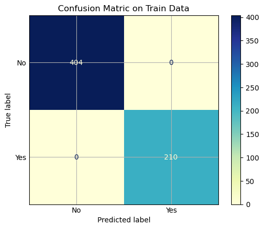

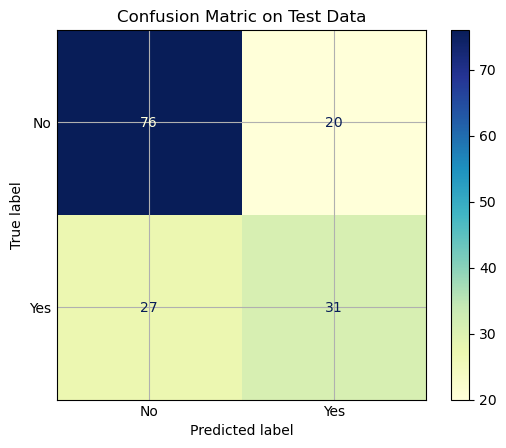

```python
get_score(model)
```

L'arbre de décision a tendance à se surajuster (overfit) et la disparité entre le rappel sur Train et Test suggère que le modèle est surajusté.

#### Affichage de l'arbre

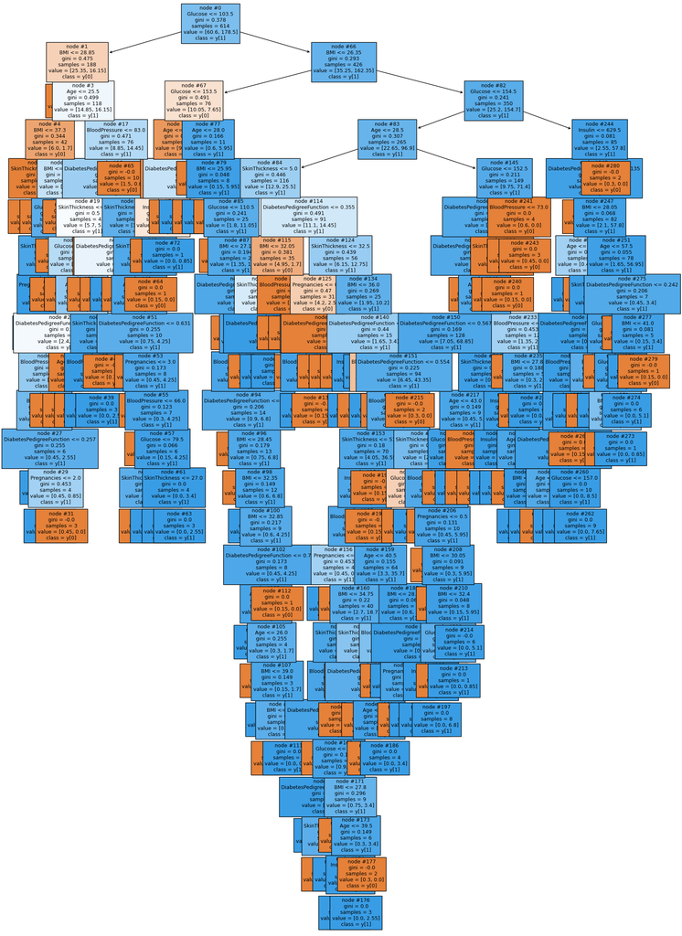

```python
column_names = list(x.columns)
feature_names = column_names
plt.figure(figsize=(20,30))
from sklearn import tree
from sklearn.model_selection import GridSearchCV
out = tree.plot_tree(model,feature_names=feature_names,filled=True,fontsize=9,node_ids=True,class_names=True)
for o in out:
     arrow = o.arrow_patch
     if arrow is not None:
        arrow.set_edgecolor('black')
        arrow.set_linewidth(1)
plt.show()
```

#### L'importance de chaque variable pour le modele

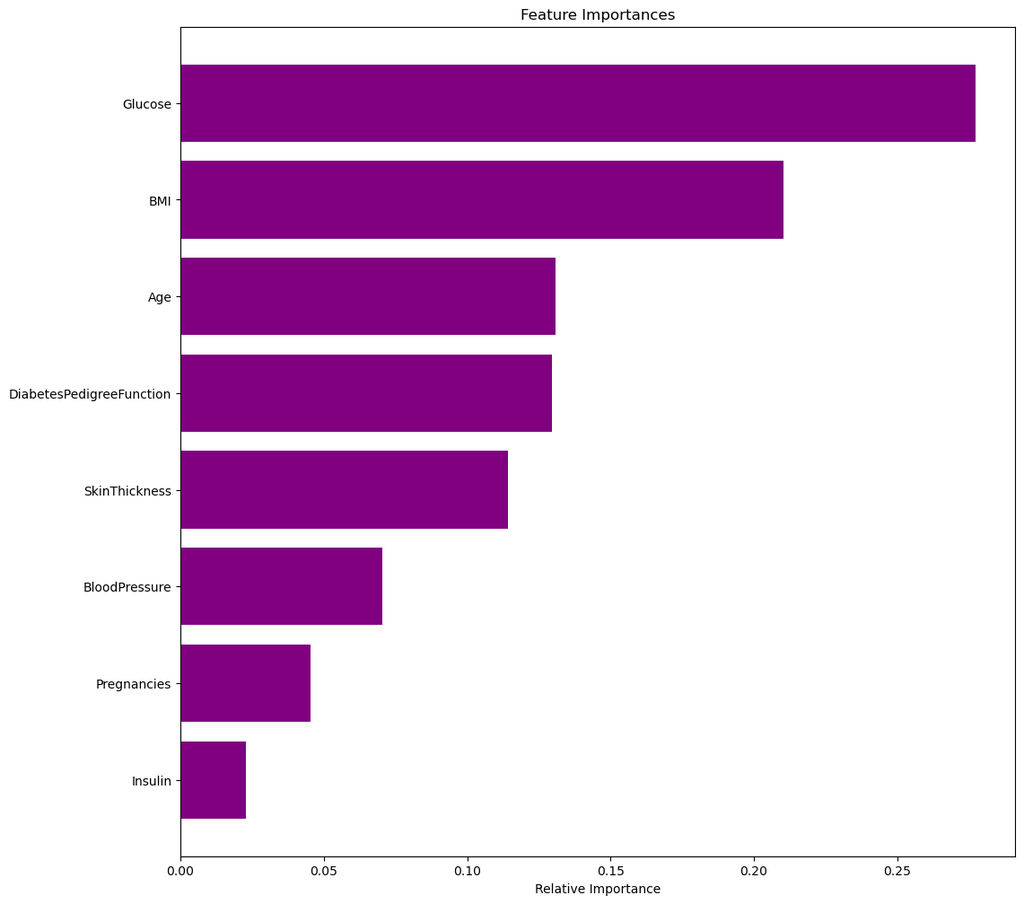

```python
importances = model.feature_importances_
indices = np.argsort(importances)

plt.figure(figsize=(12,12))
plt.title('Feature Importances')
plt.barh(range(len(indices)), importances[indices], color='purple', align='center')
plt.yticks(range(len(indices)), [feature_names[i] for i in indices])
plt.xlabel('Relative Importance')
plt.show()
```

#### L'optimisation et le choix de meilleur model

Cette partie permet d'ajuster les hyperparamètres d'un classificateur d'arbre de décision à l'aide d'une approche de recherche en grille.

La première ligne crée une instance de DecisionTreeClassifier, qui est un type de modèle d'arbre de décision couramment utilisé pour les tâches de classification.

La deuxième étape définit une grille d'hyperparamètres qui seront testés par la recherche en grille. Ces hyperparamètres sont la profondeur maximale de l'arbre, le nombre minimal d'échantillons requis pour atteindre un nœud feuille et le nombre maximal de nœuds feuilles dans l'arbre.

La troisième étape crée une fonction de notation qui sera utilisée pour comparer différentes combinaisons d'hyperparamètres. Dans ce cas, la fonction de notation est définie comme étant le score de rappel à l'aide de la fonction `make_scorer()`. Le score de rappel est une métrique qui mesure la proportion d'instances positives réelles qui sont correctement identifiées comme positives par le modèle.

La quatrième étape exécute la recherche en grille à l'aide de la fonction `GridSearchCV()`. La recherche de grille effectue une recherche exhaustive sur la grille d'hyperparamètres définie à l'étape 2 et évalue chaque combinaison d'hyperparamètres à l'aide de la validation croisée. Le paramètre `cv` spécifie le nombre de plis dans le processus de validation croisée.

La cinquième étape récupère le meilleur estimateur trouvé par la recherche en grille et l'affecte à la variable `estimateur`. Cet estimateur est le classificateur d'arbre de décision avec la combinaison optimale d'hyperparamètres qui maximise le score de rappel.

Dans l'ensemble, ce code effectue le réglage des hyperparamètres à l'aide d'une approche de recherche en grille afin d'optimiser les performances d'un classificateur d'arbre décisionnel pour une tâche de classification.

```python
# Choose the type of classifier.
estimator = DecisionTreeClassifier(random_state=1)

# Grid of parameters to choose from

parameters = {'max_depth': np.arange(1,10),
              'min_samples_leaf': [1, 2, 5, 7, 10,15,20],
              'max_leaf_nodes' : [5, 10,15,20,25,30],
              }

# Type of scoring used to compare parameter combinations
acc_scorer = make_scorer(recall_score)

# Run the grid search
grid_obj = GridSearchCV(estimator, parameters, scoring=acc_scorer,cv=5)
grid_obj = grid_obj.fit(x_train, y_train)

# Set the clf to the best combination of parameters
estimator = grid_obj.best_estimator_
estimator
```

```
DecisionTreeClassifier(max_depth=5, max_leaf_nodes=20, min_samples_leaf=15,
                       random_state=1)
```

Le paramètre `max_depth` définit la profondeur maximale de l'arbre. Il s'agit du nombre maximum de niveaux de l'arbre de décision. Dans ce cas, la valeur est fixée à 5, ce qui signifie que l'arbre de décision peut avoir jusqu'à 5 niveaux.

Le paramètre `max_leaf_nodes` fixe le nombre maximum de nœuds feuilles dans l'arbre. Un noeud feuille est un noeud qui n'a pas d'enfant (c'est-à-dire un noeud terminal). Dans ce cas, la valeur est fixée à 20, ce qui signifie que l'arbre de décision peut avoir jusqu'à 20 nœuds feuilles.

Le paramètre `min_samples_leaf` fixe le nombre minimum d'échantillons requis pour être à un noeud feuille. Ce paramètre peut être utilisé pour contrôler le surajustement. Dans ce cas, la valeur est fixée à 15, ce qui signifie qu'un noeud feuille doit avoir au moins 15 échantillons pour être créé.

Le paramètre `random_state` définit la valeur de la graine pour le générateur de nombres aléatoires utilisé par le modèle. Ce paramètre est utilisé pour s'assurer que les résultats du modèle sont reproductibles. Dans ce cas, la valeur est fixée à 1.

Globalement, cette instance de `DecisionTreeClassifier` crée un modèle d'arbre de décision avec une profondeur maximale de 5, un maximum de 20 nœuds feuilles et un minimum de 15 échantillons par nœud feuille. Le modèle utilisera un générateur de nombres aléatoires avec une graine de 1.

#### Creation de model optimisé et affichage de la nouvelle arbre

```python
# Fit the best algorithm to the data.
estimator.fit(x_train, y_train)
ytrain_predict=estimator.predict(x_train)
ytest_predict=estimator.predict(x_test)
```

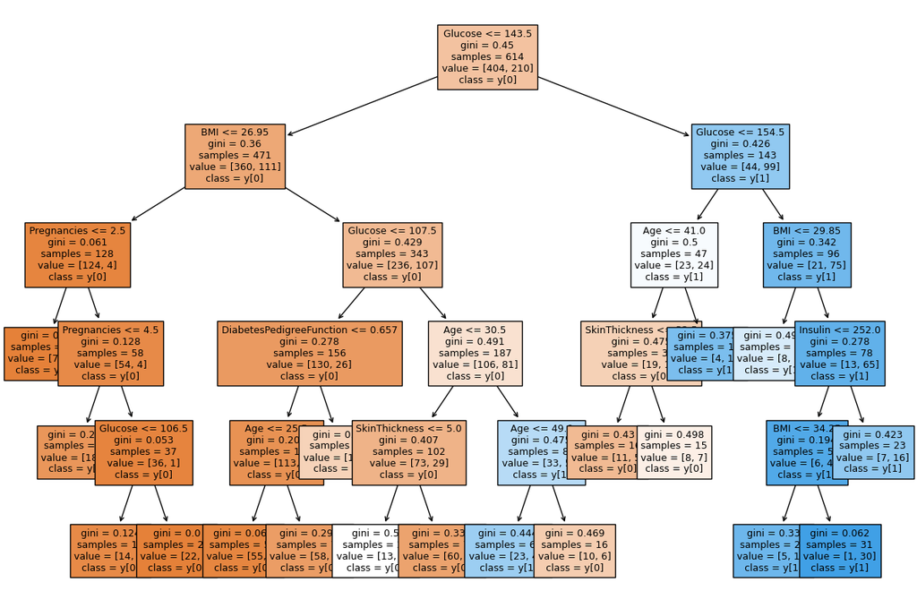

```python
plt.figure(figsize=(15,10))

out = tree.plot_tree(estimator,feature_names=feature_names,filled=True,fontsize=9,node_ids=False,class_names=True)
for o in out:
    arrow = o.arrow_patch
    if arrow is not None:
        arrow.set_edgecolor('black')
        arrow.set_linewidth(1)
plt.show()
```

#### L'importance de chaque variable pour le modele

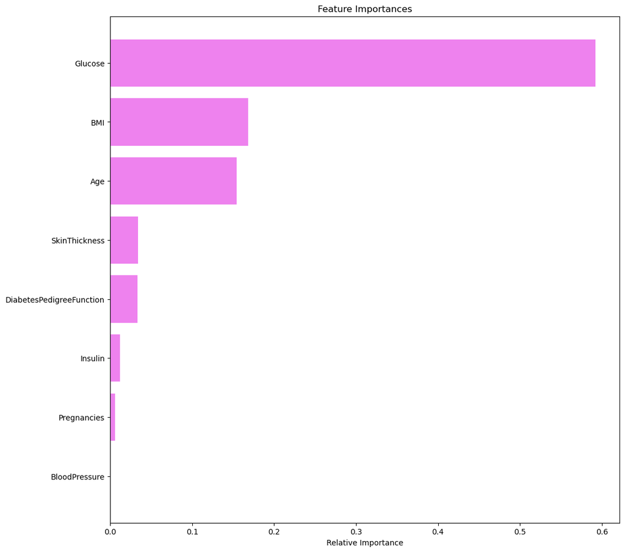

```python
importances = estimator.feature_importances_
indices = np.argsort(importances)

plt.figure(figsize=(12,12))
plt.title('Feature Importances')
plt.barh(range(len(indices)), importances[indices], color='violet', align='center')
plt.yticks(range(len(indices)), [feature_names[i] for i in indices])
plt.xlabel('Relative Importance')
plt.show()
```

#### Evaluation de model optimisé

```
 Accuracy : Train : 0.7964169381107492  Test: 0.7662337662337663
 Recall   : Train : 0.6333333333333333  Test: 0.603448275862069
 Precision   : Train : 0.7348066298342542  Test: 0.7291666666666666
```

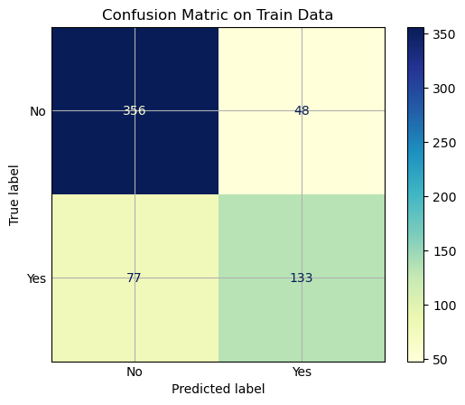

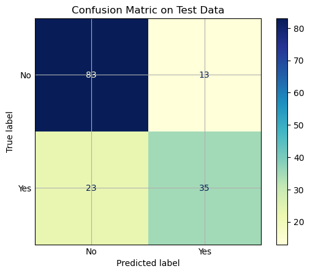

```python
get_score(estimator)
```

#### Optimisation de model par le choix de alpha qui maximise le recall

J'ai choisi le modèle qui maximise le recall parce qu'il vaut mieux avoir des faux positifs que des faux négatifs dans ce cas.

```python
clf = estimator
path = clf.cost_complexity_pruning_path(x_train, y_train)
ccp_alphas, impurities = path.ccp_alphas, path.impurities
```

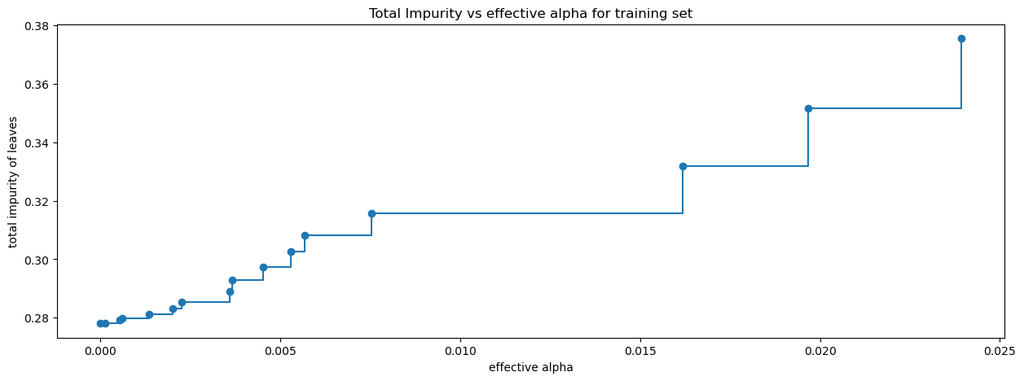

```python
fig, ax = plt.subplots(figsize=(15,5))
ax.plot(ccp_alphas[:-1], impurities[:-1], marker='o', drawstyle="steps-post")
ax.set_xlabel("effective alpha")
ax.set_ylabel("total impurity of leaves")
ax.set_title("Total Impurity vs effective alpha for training set")
plt.show()
```

```python
clfs = []
accuracy_train=[]
accuracy_test=[]
recall_train=[]
recall_test=[]
for ccp_alpha in ccp_alphas:
    clf = DecisionTreeClassifier(random_state=1, ccp_alpha=ccp_alpha,class_weight = {0:0.15,1:0.85})
    clf.fit(x_train, y_train)
    y_train_pred=clf.predict(x_train)
    y_test_pred=clf.predict(x_test)
    accuracy_train.append(clf.score(x_train,y_train))
    accuracy_test.append(clf.score(x_test,y_test))
    recall_train.append(recall_score(y_train,y_train_pred))
    recall_test.append(recall_score(y_test,y_test_pred))
    clfs.append(clf)
```

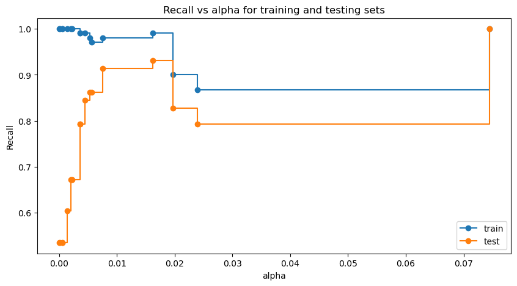

```python
fig, ax = plt.subplots(figsize=(10,5))
ax.set_xlabel("alpha")
ax.set_ylabel("Recall")
ax.set_title("Recall vs alpha for training and testing sets")
ax.plot(ccp_alphas, recall_train, marker='o', label="train",
        drawstyle="steps-post")
ax.plot(ccp_alphas, recall_test, marker='o', label="test",
        drawstyle="steps-post")
ax.legend()
plt.show()
```

```python
best_model = DecisionTreeClassifier(max_depth=5, max_leaf_nodes=20, min_samples_leaf=15,ccp_alpha=0.019,
                       class_weight={0: 0.15, 1: 0.85}, random_state=1)
best_model.fit(x_train, y_train)
```

```
DecisionTreeClassifier(ccp_alpha=0.019, class_weight={0: 0.15, 1: 0.85},
                       max_depth=5, max_leaf_nodes=20, min_samples_leaf=15,
                       random_state=1)
```

```
 Accuracy : Train : 0.6807817589576547  Test: 0.6818181818181818
 Recall   : Train : 0.8666666666666667  Test: 0.7931034482758621
 Precision   : Train : 0.52  Test: 0.5542168674698795
```

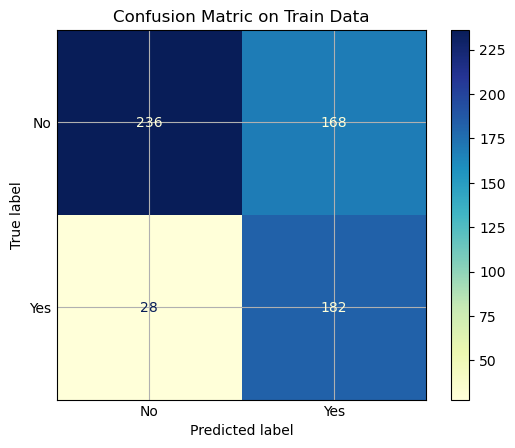

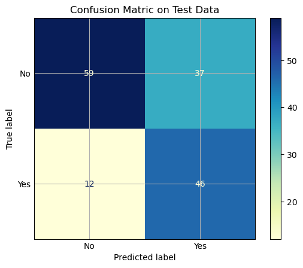

```python
get_score(best_model)
```

#### Affichage de l'arbre de meilleur model

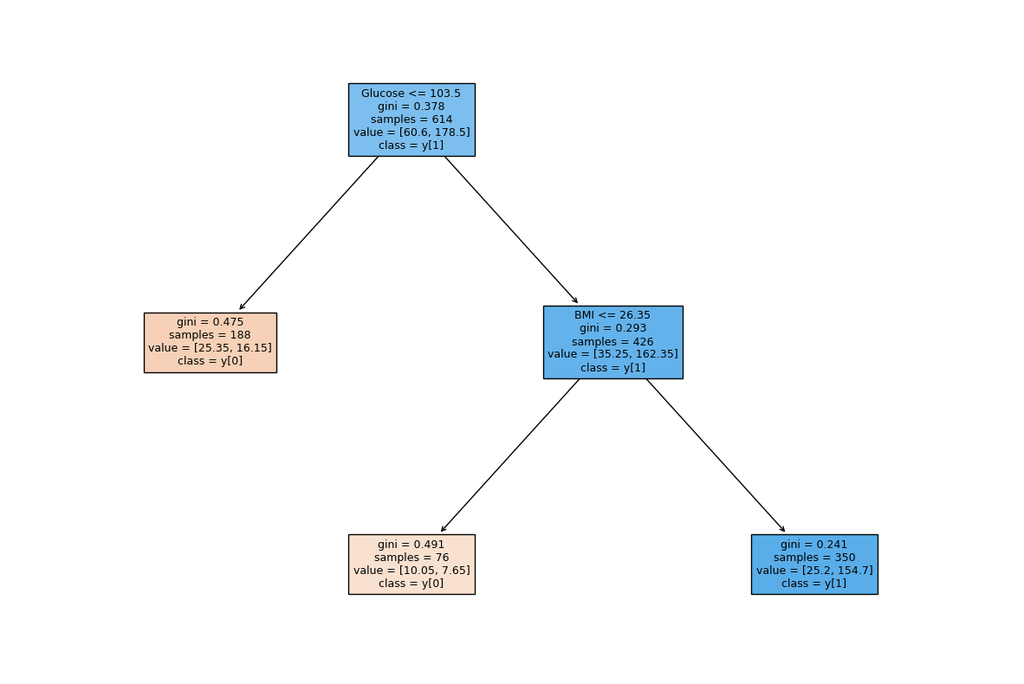

```python
plt.figure(figsize=(15,10))

out = tree.plot_tree(best_model,feature_names=feature_names,filled=True,fontsize=9,node_ids=False,class_names=True)
for o in out:
    arrow = o.arrow_patch
    if arrow is not None:
        arrow.set_edgecolor('black')
        arrow.set_linewidth(1)
plt.show()
```

#### Importance des variables pour le model

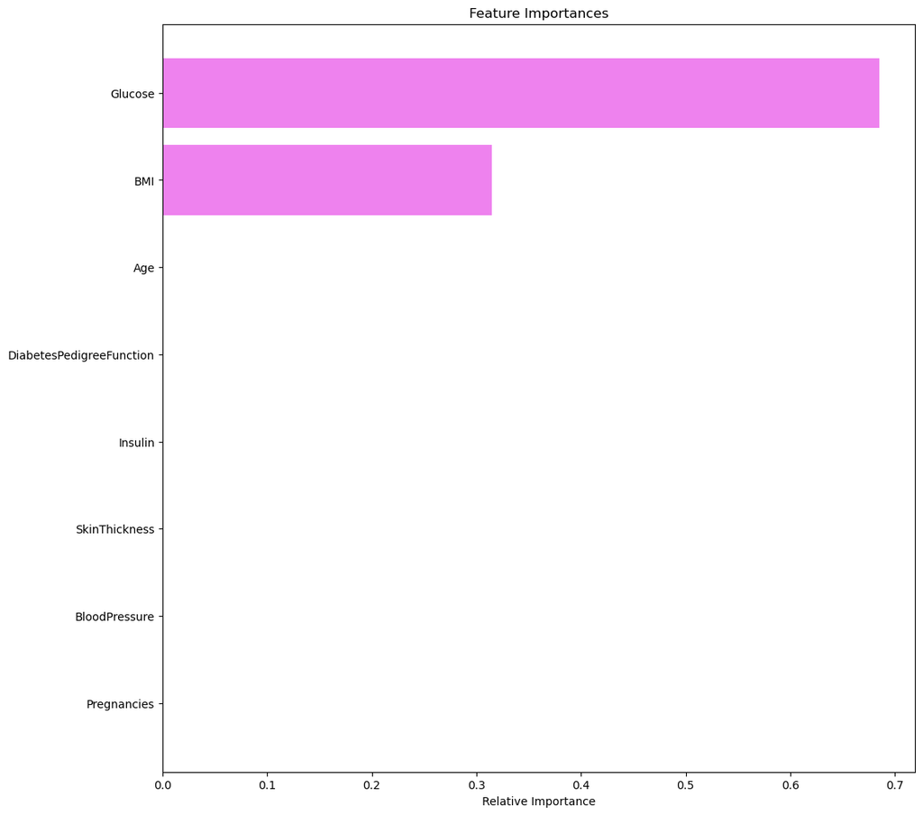

```python
importances = best_model.feature_importances_
indices = np.argsort(importances)

plt.figure(figsize=(12,12))
plt.title('Feature Importances')
plt.barh(range(len(indices)), importances[indices], color='violet', align='center')
plt.yticks(range(len(indices)), [feature_names[i] for i in indices])
plt.xlabel('Relative Importance')
plt.show()
```

#### Evaluation de model

```python
y_pred = best_model.predict(x_test)
print(classification_report(y_test,y_pred))
```

```
              precision    recall  f1-score   support

           0       0.83      0.61      0.71        96
           1       0.55      0.79      0.65        58

    accuracy                           0.68       154
   macro avg       0.69      0.70      0.68       154
weighted avg       0.73      0.68      0.69       154
```

```python
#use model to predict probability that given y value is 1
y_pred_proba = best_model.predict_proba(x_test)[::,1]

#calculate AUC of model
auc = roc_auc_score(y_test, y_pred_proba)

#print AUC score
print(auc)
```

```
0.720635775862069
```

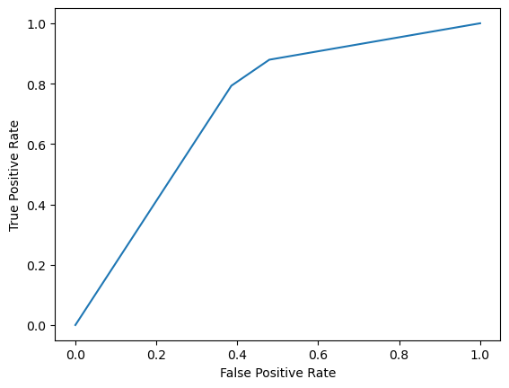

```python
def plot_roc_curve(true_y, y_prob):
    """
    plots the roc curve based of the probabilities
    """

    fpr, tpr, thresholds = roc_curve(true_y, y_prob)
    plt.plot(fpr, tpr)
    plt.xlabel('False Positive Rate')
    plt.ylabel('True Positive Rate')
plot_roc_curve(y_test, y_pred_proba)
```

### Random Forest

#### Creation de model

```python
rfc=RandomForestClassifier()
rfc.fit(x_train,y_train)
```

```
RandomForestClassifier()
```

##### Les parametres de model

```python
rfc.get_params()
```

```
{'bootstrap': True,
 'ccp_alpha': 0.0,
 'class_weight': None,
 'criterion': 'gini',
 'max_depth': None,
 'max_features': 'auto',
 'max_leaf_nodes': None,
 'max_samples': None,
 'min_impurity_decrease': 0.0,
 'min_samples_leaf': 1,
 'min_samples_split': 2,
 'min_weight_fraction_leaf': 0.0,
 'n_estimators': 100,
 'n_jobs': None,
 'oob_score': False,
 'random_state': None,
 'verbose': 0,
 'warm_start': False}
```

Le modele a comme parametres:

n_estimators : Le nombre d'arbres de décision dans la forêt aléatoire. Dans ce cas, le nombre optimal d'arbres est de 100.

min_samples_split : Le nombre minimum d'échantillons requis pour diviser un nœud interne. La valeur de 2 indique que l'algorithme ne divisera un nœud que s'il contient au moins 2 échantillons.

min_samples_leaf : Le nombre minimum d'échantillons requis pour être à un nœud feuille. La valeur de 1 indique que chaque nœud feuille doit avoir au moins 1 échantillons.

max_features : Le nombre maximum de fonctionnalités à considérer lors de la recherche de la meilleure division. Dans ce cas, la valeur est "auto".

bootstrap : Que les échantillons utilisés pour chaque arbre sont bootstrapés ou non. La valeur de True signifie que les échantillons sont tirés au hasard avec remplacement.

#### Prediction et Evaluation

```python
y_pred=rfc.predict(x_test)
print("Classification Report is:\n",classification_report(y_test,y_pred))
cnfu_matrix=confusion_matrix(y_test,y_pred)
```

```
Classification Report is:
               precision    recall  f1-score   support

           0       0.84      0.86      0.85        96
           1       0.76      0.72      0.74        58

    accuracy                           0.81       154
   macro avg       0.80      0.79      0.80       154
weighted avg       0.81      0.81      0.81       154
```

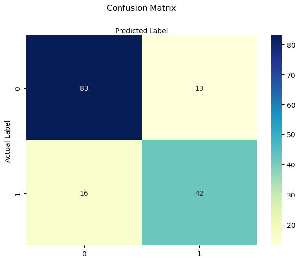

```python
#plotting confusion matrix
class_names = [0,1]
fig, ax = plt.subplots()
tick_marks = np.arange(len(class_names))
plt.xticks(tick_marks, class_names)
plt.yticks(tick_marks, class_names)

#create heatmap
sns.heatmap(pd.DataFrame(cnfu_matrix), annot=True, cmap="YlGnBu", fmt='g')
ax.xaxis.set_label_position("top")
plt.tight_layout()
plt.title('Confusion Matrix', y=1.1)
plt.ylabel('Actual Label')
plt.xlabel('Predicted Label')
```

```python
print(accuracy_score(y_test,y_pred))
```

```
0.8116883116883117
```

```python
#use model to predict probability that given y value is 1
y_pred_proba = rfc.predict_proba(x_test)[::,1]

#calculate AUC of model
auc = roc_auc_score(y_test, y_pred_proba)

#print AUC score
print(auc)
```

```
0.8651221264367815
```

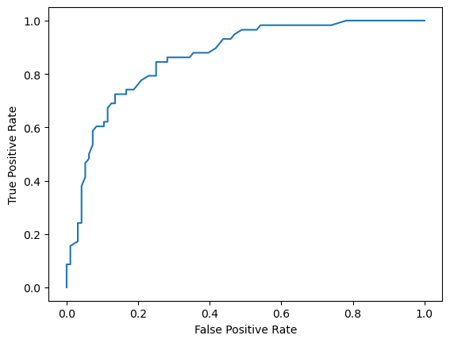

```python
def plot_roc_curve(true_y, y_prob):
    """
    plots the roc curve based of the probabilities
    """

    fpr, tpr, thresholds = roc_curve(true_y, y_prob)
    plt.plot(fpr, tpr)
    plt.xlabel('False Positive Rate')
    plt.ylabel('True Positive Rate')
plot_roc_curve(y_test, y_pred_proba)
```

#### Réglage des hyperparamètres à l'aide de RandomizedSearch CV

```python
n_estimators = [5,20,50,100] # number of trees in the random forest
max_features = ['auto', 'sqrt'] # number of features in consideration at every split
max_depth = [int(x) for x in np.linspace(10, 120, num = 12)] # maximum number of levels allowed in each decision tree
min_samples_split = [2, 6, 10] # minimum sample number to split a node
min_samples_leaf = [1, 3, 4] # minimum sample number that can be stored in a leaf node
bootstrap = [True, False] # method used to sample data points

random_grid = {'n_estimators': n_estimators,

'max_features': max_features,

'max_depth': max_depth,

'min_samples_split': min_samples_split,

'min_samples_leaf': min_samples_leaf,

'bootstrap': bootstrap}
```

#### Creation de model optimisé

```python
rfc_random = RandomizedSearchCV(estimator = rfc,param_distributions = random_grid,
               n_iter = 100, cv = 5, verbose=2, random_state=123, n_jobs = -1)
```

```python
rfc_random.fit(x_train, y_train)
```

```
Fitting 5 folds for each of 100 candidates, totalling 500 fits
```

```
RandomizedSearchCV(cv=5, estimator=RandomForestClassifier(), n_iter=100,
                   n_jobs=-1,
                   param_distributions={'bootstrap': [True, False],
                                        'max_depth': [10, 20, 30, 40, 50, 60,
                                                      70, 80, 90, 100, 110,
                                                      120],
                                        'max_features': ['auto', 'sqrt'],
                                        'min_samples_leaf': [1, 3, 4],
                                        'min_samples_split': [2, 6, 10],
                                        'n_estimators': [5, 20, 50, 100]},
                   random_state=123, verbose=2)
```

##### Imprimer les meilleures parametres

```python
print ('Random grid: ', random_grid, '\n')
# print the best parameters
print ('Best Parameters: ', rfc_random.best_params_, ' \n')
```

```
Random grid:  {'n_estimators': [5, 20, 50, 100], 'max_features': ['auto', 'sqrt'], 'max_depth': [10, 20, 30, 40, 50, 60, 70, 80, 90, 100, 110, 120], 'min_samples_split': [2, 6, 10], 'min_samples_leaf': [1, 3, 4], 'bootstrap': [True, False]}

Best Parameters:  {'n_estimators': 50, 'min_samples_split': 6, 'min_samples_leaf': 3, 'max_features': 'auto', 'max_depth': 70, 'bootstrap': True}
```

les parametres optimaux sont :

n_estimators : Le nombre d'arbres de décision dans la forêt aléatoire. Dans ce cas, le nombre optimal d'arbres est de 50.

min_samples_split : Le nombre minimum d'échantillons requis pour diviser un nœud interne. La valeur de 6 indique que l'algorithme ne divisera un nœud que s'il contient au moins 6 échantillons.

min_samples_leaf : Le nombre minimum d'échantillons requis pour être à un nœud feuille. La valeur de 3 indique que chaque nœud feuille doit avoir au moins 3 échantillons.

max_features : Le nombre maximum de fonctionnalités à considérer lors de la recherche de la meilleure division. Dans ce cas, la valeur est "auto" .

max_depth : La profondeur maximale de chaque arbre de décision dans la forêt aléatoire. La valeur de 70 indique que la profondeur maximale est de 70 niveaux.

bootstrap : Que les échantillons utilisés pour chaque arbre sont bootstrapés ou non. La valeur de True signifie que les échantillons sont tirés au hasard avec remplacement.

Dans l'ensemble, ces hyperparamètres sont choisis pour optimiser l'équilibre entre le biais et la variance dans le modèle, ce qui peut conduire aux meilleures performances sur l'ensemble de données.

##### Utilisation des meilleures parametres

```python
randmf = RandomForestClassifier(n_estimators = 50, min_samples_split = 6, min_samples_leaf= 3, max_features = 'auto', max_depth= 70, bootstrap=True)
randmf.fit( x_train, y_train)
```

```
RandomForestClassifier(max_depth=70, min_samples_leaf=3, min_samples_split=6,
                       n_estimators=50)
```

#### Evaluation de model

```python
y_pred=randmf.predict(x_test)
print("Classification Report is:\n",classification_report(y_test,y_pred))
cnfu_matrix=confusion_matrix(y_test,y_pred)
```

```
Classification Report is:
               precision    recall  f1-score   support

           0       0.83      0.88      0.85        96
           1       0.77      0.71      0.74        58

    accuracy                           0.81       154
   macro avg       0.80      0.79      0.80       154
weighted avg       0.81      0.81      0.81       154
```

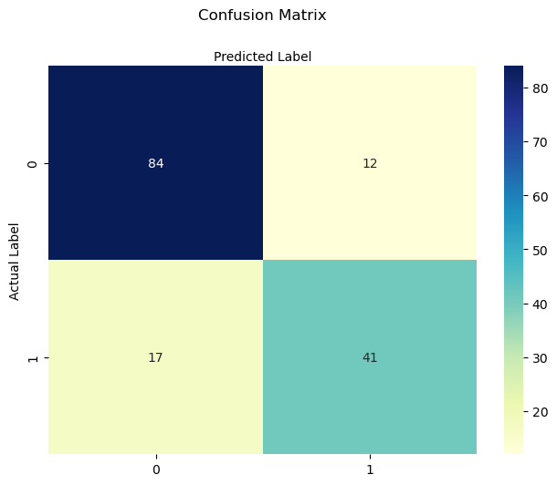

```python
#plotting confusion matrix
class_names = [0,1]
fig, ax = plt.subplots()
tick_marks = np.arange(len(class_names))
plt.xticks(tick_marks, class_names)
plt.yticks(tick_marks, class_names)

#create heatmap
sns.heatmap(pd.DataFrame(cnfu_matrix), annot=True, cmap="YlGnBu", fmt='g')
ax.xaxis.set_label_position("top")
plt.tight_layout()
plt.title('Confusion Matrix', y=1.1)
plt.ylabel('Actual Label')
plt.xlabel('Predicted Label')
```

```python
print(accuracy_score(y_test,y_pred))
```

```
0.8116883116883117
```

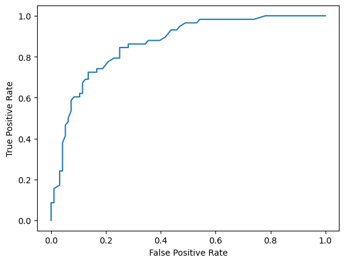

```python
def plot_roc_curve(true_y, y_prob):
    """
    plots the roc curve based of the probabilities
    """

    fpr, tpr, thresholds = roc_curve(true_y, y_prob)
    plt.plot(fpr, tpr)
    plt.xlabel('False Positive Rate')
    plt.ylabel('True Positive Rate')
plot_roc_curve(y_test, y_pred_proba)
```